# Analysis for San Francisco Bay Ford GoBike Service 2019

## Oni Oluwasegun Yemi

## Investigation Overview

In this report, I want to explore the features that influences bike duration. Also, to explore the interactions that exists within other variables in the dataset.

## Dataset Overview

The dataset contians 183412 bikers attributes for the Ford GoBike dataset. The major attributes of the dataset are trip duration, ride start and end time, station route, member's age, gender and bike user type.

## Distribution of Ride duration

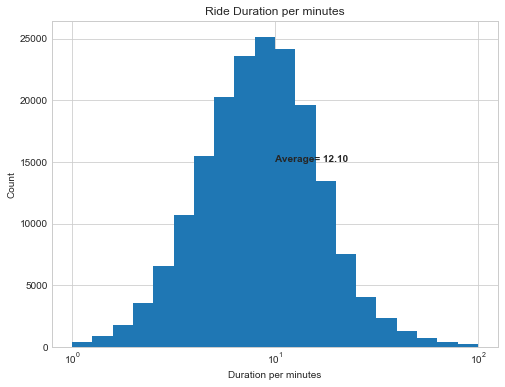

## Distribution of Age

The five point summary statistics values are clearly observed on the plot. The minimum age value is lesser than 20, the first quartile is less than 30, the median age is above 30 but lesser than 35. The Q3 is between 35-40 and the maximum age value is close to 55 years. There is an indication of three outliers.

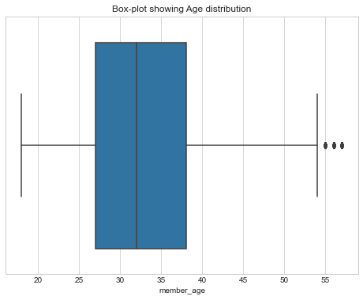

## Distribution of Gender

The pie chart shows the distribution of bike riders gender. Majority (74.6%) are Male, 23.3% are female and about 2.1% belongs to other gender catrgory

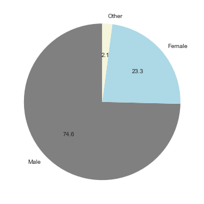

# Age Vs. Trip Duration

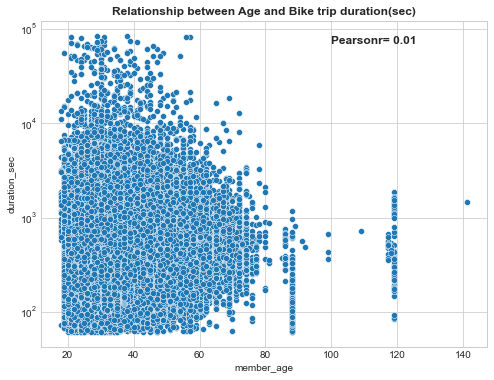

# User type Vs. Duration

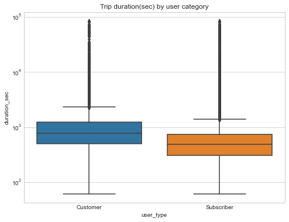

# Ride Frequency

5PM and 8AM are observed to be the most popular hours for using the Ford GoBike. Also, Mid-weeks tends to have higher frequency ride compared to weekends which are litte or less popular during the peak ride hours.

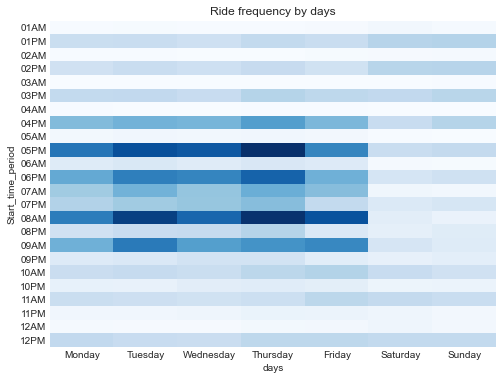

# Top Route based on Average trip per minutes

The most popular route based on average ride per minutes is between 11th St at Natoma St and 16th St Depot. follwed by Route between Scott St at Golden Gate Ave and McAllister St, and Powell St BART staion and 16th St Depot.

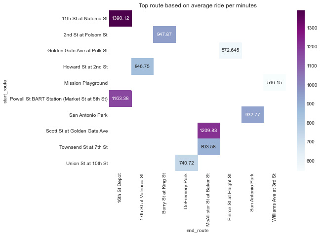